# Qwen3.8 text-only validity: primary analysis

Eight TOSTs, conjunction, Bland Altman, and the sampling frame ledger

# 1 What this document answers

The preregistered design is set out in `docs/framework-empirical-evaluation-qwen38.md`, which reuses `docs/framework-empirical-evaluation.md` for hypotheses, outcomes, and analysis. This Quarto document is the primary analysis of that design and is written as a confirmatory report rather than as an exploratory notebook.

The estimand is the mean relative error on the executable family-like grid. A **subject** is one architecture together with one $(B, S)$. Each subject contributes one relative error to each of eight cells formed by the crossing of phase, precision, and hypothesis. Additional training steps do not increase the sample size $n$.

Table 1: Columns that enter each hypothesis as the Zepto prediction $y$ and the twin probe $t$.

| Hypothesis | Zepto column $y$ | Twin column $t$ |
| --- | --- | --- |
| H1 VRAM | `y_vram` | `target_vram` |
| H2 FLOPs | `y_flop_fcm` | `target_flop` |

The relative error is defined in Equation 1.

$$\mathrm{RE} = \frac{y - t}{t}
\tag{1}$$

The equivalence margin is $\Delta = 0.10$ and the significance level is $\alpha = 0.05$ for each pair of one sided tests. Multiplicity is not adjusted with a Bonferroni correction. Family validity is the **conjunction** of all eight TOSTs, so the family claim is supported only when every cell declares equivalence. An inconclusive TOST does not constitute evidence that Zepto is inaccurate to ten percent.

The column `y_flop` is stored on the CSV as a diagnostic and is not the column used for H2.

The following chunk loads TOSTER, defines relative error, and reads the evaluation table together with the ledger.

```r
required <- c("TOSTER")
missing <- required[!vapply(required, requireNamespace, logical(1), quietly = TRUE)]
if (length(missing) > 0) {
  stop("Install missing R packages: ", paste(missing, collapse = ", "),
       "\n  install.packages(c(\"TOSTER\"))", call. = FALSE)
}

relative_error <- function(y, t) {
  if (any(t == 0, na.rm = TRUE)) {
    stop("twin probe t must be non-zero", call. = FALSE)
  }
  (y - t) / t
}

MARGIN <- 0.10
ALPHA <- 0.05

evaluation <- read.csv(params$evaluation, stringsAsFactors = FALSE)
ledger_path <- params$ledger
ledger <- if (file.exists(ledger_path)) {
  read.csv(ledger_path, stringsAsFactors = FALSE)
} else {
  data.frame()
}

needed <- c(
  "subject_id", "phase", "precision",
  "y_vram", "target_vram", "y_flop_fcm", "target_flop"
)
missing_cols <- setdiff(needed, names(evaluation))
if (length(missing_cols) > 0) {
  stop("evaluation.csv missing: ", paste(missing_cols, collapse = ", "),
       call. = FALSE)
}

evaluation$re_vram <- relative_error(evaluation$y_vram, evaluation$target_vram)
evaluation$re_flop <- relative_error(evaluation$y_flop_fcm, evaluation$target_flop)
```

# 2 Data

The primary analysis uses **completed subjects only**. The ledger is retained as the sampling frame appendix described in framework section 5.3. Table 2 reports how many evaluation rows and completed subject identifiers are present, together with the number of ledger rows.

```r
n_rows <- nrow(evaluation)
n_subjects <- length(unique(evaluation$subject_id))
n_ledger <- if (nrow(ledger) == 0) 0 else nrow(ledger)

knitr::kable(
  data.frame(
    evaluation_rows = n_rows,
    completed_subject_ids = n_subjects,
    ledger_rows = n_ledger
  )
)
```

Table 2: Completed measurements versus ledger rows.

| evaluation_rows | completed_subject_ids | ledger_rows |
| --- | --- | --- |
| 32 | 8 | 1 |

# 3 Eight one sample TOSTs

For each cell the tests follow framework section 5.1. The first one sided test is $H_{01}\colon \mu \le -0.10$ versus $H_{11}\colon \mu > -0.10$, and the second is $H_{02}\colon \mu \ge +0.10$ versus $H_{12}\colon \mu < +0.10$. Equivalence is declared only if both one sided tests reject, and the two `t.test` calls below implement that definition.

`TOSTER::t_TOST` packages the same two one sided tests following Lakens and Caldwell. It is used only as confirmation and does not decide the cell. H2 inference can have a relative error standard deviation of zero when every subject’s `y_flop_fcm` equals `target_flop`. That configuration remains a valid TOST input, with $t = \pm\infty$. TOSTER 0.8.6 still tries to invert a noncentral $t$ for a Cohen’s $d$ interval through `get_ncp_t2` and then errors with `object 'Best.Low' not found`. Confirmation is therefore skipped when the standard deviation is zero. Table 3 reports the eight cells.

```r
cells <- expand.grid(
  hypothesis = c("vram", "flop"),
  phase = c("inference", "training"),
  precision = c("fp16", "fp32"),
  stringsAsFactors = FALSE
)

tost_one_cell <- function(hypothesis, phase, precision) {
  part <- evaluation[
    evaluation$phase == phase & evaluation$precision == precision,
  ]
  part <- part[!duplicated(part$subject_id), ]
  re <- if (hypothesis == "vram") part$re_vram else part$re_flop
  re <- re[is.finite(re)]
  n <- length(re)
  if (n < 2) {
    return(data.frame(
      hypothesis = hypothesis,
      phase = phase,
      precision = precision,
      n = n,
      mean_re = NA_real_,
      sd_re = NA_real_,
      p_lower = NA_real_,
      p_upper = NA_real_,
      equivalent = FALSE,
      decision = "not_enough_n",
      stringsAsFactors = FALSE
    ))
  }

  # Written-out two one-sided tests (Schuirmann 1987).
  # Zero SD is allowed: all observations equal, t is ±Inf.
  lower <- t.test(re, alternative = "greater", mu = -MARGIN)
  upper <- t.test(re, alternative = "less", mu = MARGIN)
  both_reject <- (lower$p.value < ALPHA) && (upper$p.value < ALPHA)

  # Packaged confirmation (Lakens 2017). Skip when SD is 0: TOSTER's
  # Cohen's d CI helper does not accept an infinite t-statistic.
  sd_re <- stats::sd(re)
  if (is.finite(sd_re) && sd_re > 0) {
    invisible(TOSTER::t_TOST(
      x = re,
      hypothesis = "EQU",
      eqb = MARGIN,
      eqbound_type = "raw",
      alpha = ALPHA
    ))
  }

  decision <- if (both_reject) {
    "equivalent"
  } else {
    "inconclusive_or_not_equivalent"
  }

  data.frame(
    hypothesis = hypothesis,
    phase = phase,
    precision = precision,
    n = n,
    mean_re = mean(re),
    sd_re = sd_re,
    p_lower = unname(lower$p.value),
    p_upper = unname(upper$p.value),
    equivalent = both_reject,
    decision = decision,
    stringsAsFactors = FALSE
  )
}

tost_table <- do.call(
  rbind,
  Map(tost_one_cell, cells$hypothesis, cells$phase, cells$precision)
)
rownames(tost_table) <- NULL

knitr::kable(
  tost_table[, c(
    "hypothesis", "phase", "precision", "n",
    "mean_re", "sd_re", "p_lower", "p_upper", "equivalent", "decision"
  )],
  digits = 4
)
```

Table 3: One sample TOST per phase, precision, and hypothesis. p_lower is H01 and p_upper is H02.

| hypothesis | phase | precision | n | mean_re | sd_re | p_lower | p_upper | equivalent | decision |
| --- | --- | --- | --- | --- | --- | --- | --- | --- | --- |
| vram | inference | fp16 | 8 | 3e-04 | 0.0141 | 0 | 0 | TRUE | equivalent |
| flop | inference | fp16 | 8 | 3e-04 | 0.0141 | 0 | 0 | TRUE | equivalent |
| vram | training | fp16 | 8 | 3e-04 | 0.0141 | 0 | 0 | TRUE | equivalent |
| flop | training | fp16 | 8 | 3e-04 | 0.0141 | 0 | 0 | TRUE | equivalent |
| vram | inference | fp32 | 8 | 3e-04 | 0.0141 | 0 | 0 | TRUE | equivalent |
| flop | inference | fp32 | 8 | 3e-04 | 0.0141 | 0 | 0 | TRUE | equivalent |
| vram | training | fp32 | 8 | 3e-04 | 0.0141 | 0 | 0 | TRUE | equivalent |
| flop | training | fp32 | 8 | 3e-04 | 0.0141 | 0 | 0 | TRUE | equivalent |

# 4 Conjunction

The family claim holds only if every cell in Table 3 is marked `equivalent`. The following chunk states whether that conjunction holds and lists any cell that did not declare equivalence.

```r
family_pass <- all(tost_table$equivalent)
cat(
  if (family_pass) {
    "Conjunction: PASS. All eight TOSTs declared equivalence."
  } else {
    paste(
      "Conjunction: FAIL.",
      "At least one cell is not equivalent or is inconclusive.",
      "An inconclusive cell is not evidence that Zepto is inaccurate to 10%."
    )
  },
  "\n"
)
```

```
Conjunction: PASS. All eight TOSTs declared equivalence.
```

```r
knitr::kable(
  tost_table[!tost_table$equivalent, c("hypothesis", "phase", "precision", "decision")],
  caption = "Cells that did not declare equivalence (empty if the conjunction passed)."
)
```

Cells that did not declare equivalence (empty if the conjunction passed).

| hypothesis | phase | precision | decision |
| --- | --- | --- | --- |

# 5 Bland Altman

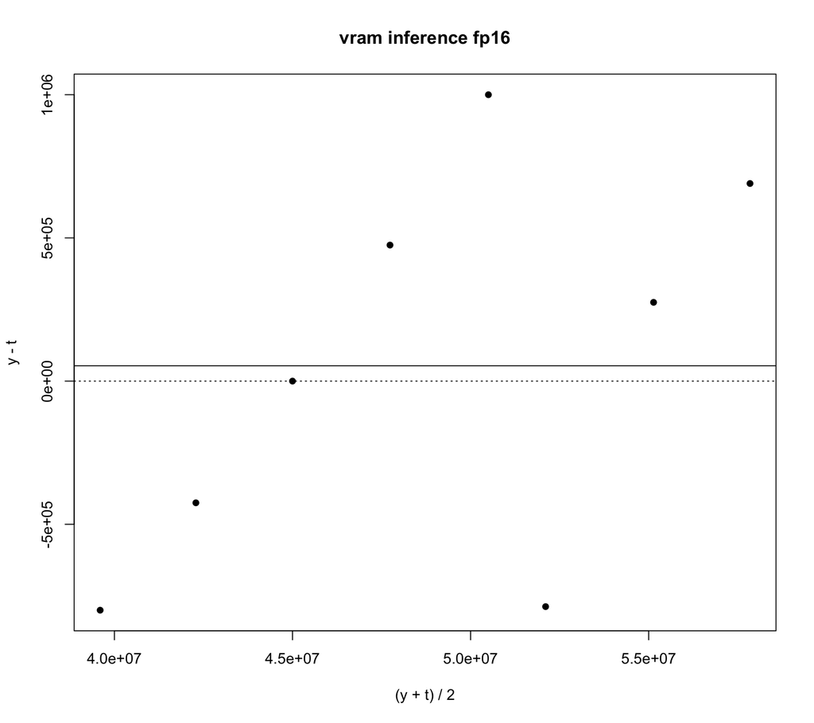

Figure 1: Bland Altman panels for each phase, precision, and hypothesis. The horizontal axis is the pairwise average and the vertical axis is the signed difference.

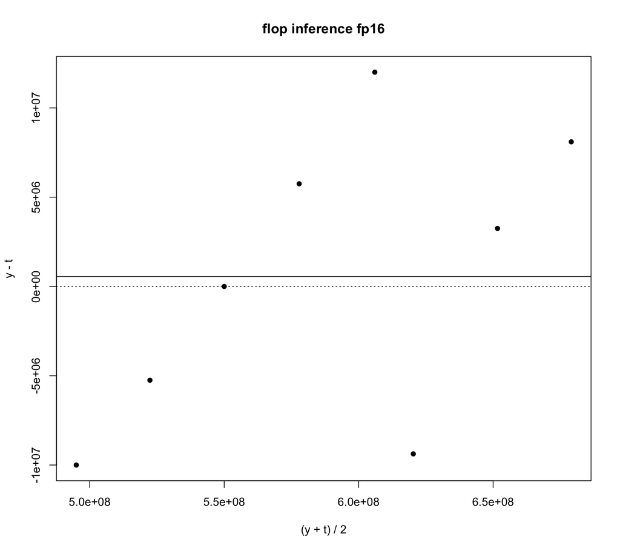

Figure 2: Bland Altman panels for each phase, precision, and hypothesis. The horizontal axis is the pairwise average and the vertical axis is the signed difference.

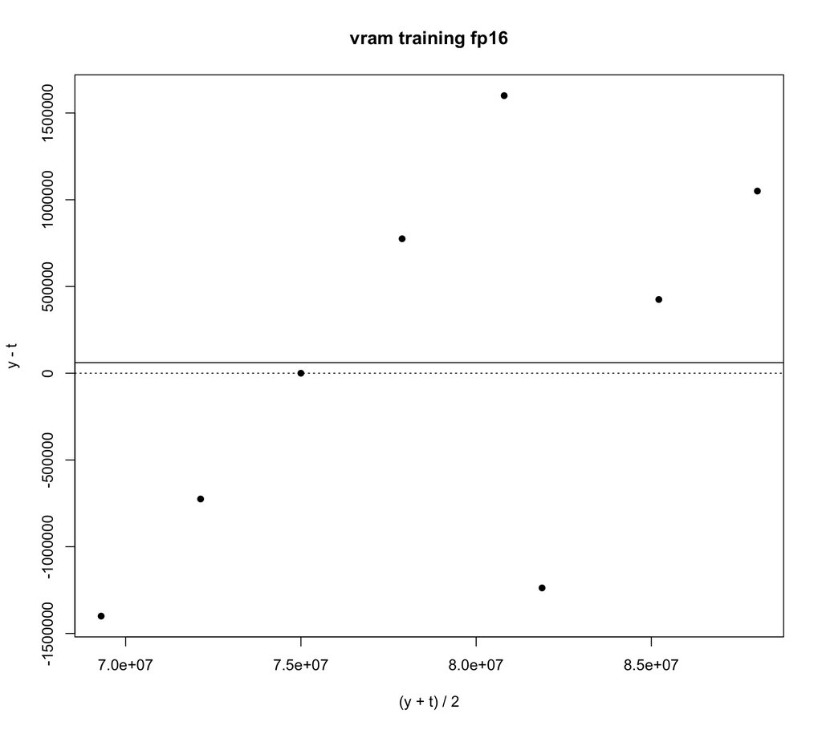

Figure 3: Bland Altman panels for each phase, precision, and hypothesis. The horizontal axis is the pairwise average and the vertical axis is the signed difference.

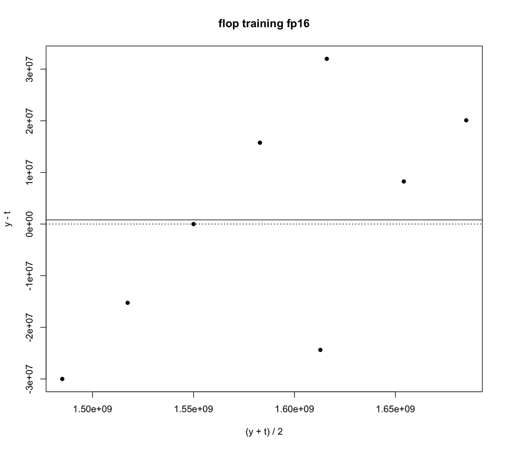

Figure 4: Bland Altman panels for each phase, precision, and hypothesis. The horizontal axis is the pairwise average and the vertical axis is the signed difference.

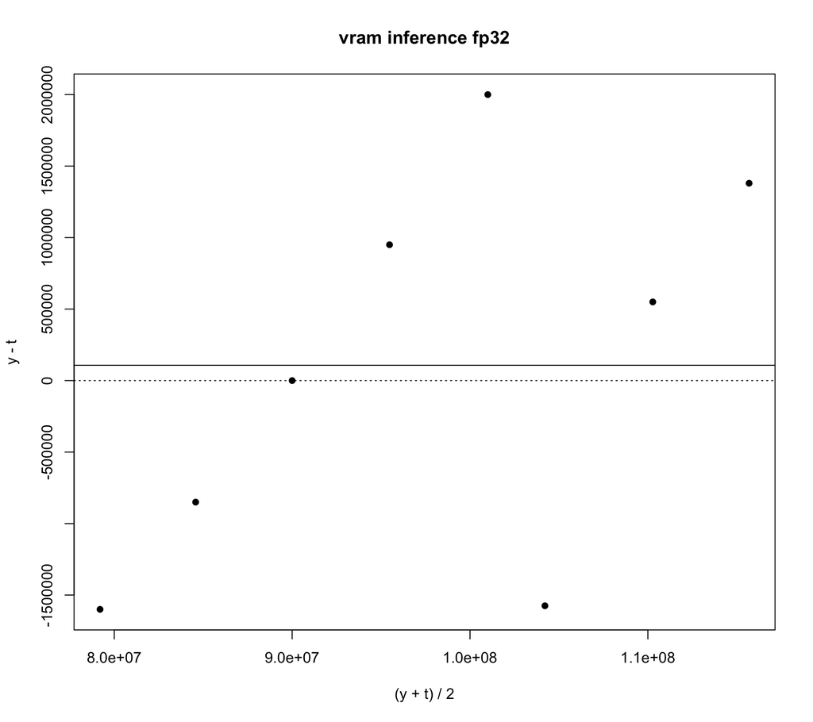

Figure 5: Bland Altman panels for each phase, precision, and hypothesis. The horizontal axis is the pairwise average and the vertical axis is the signed difference.

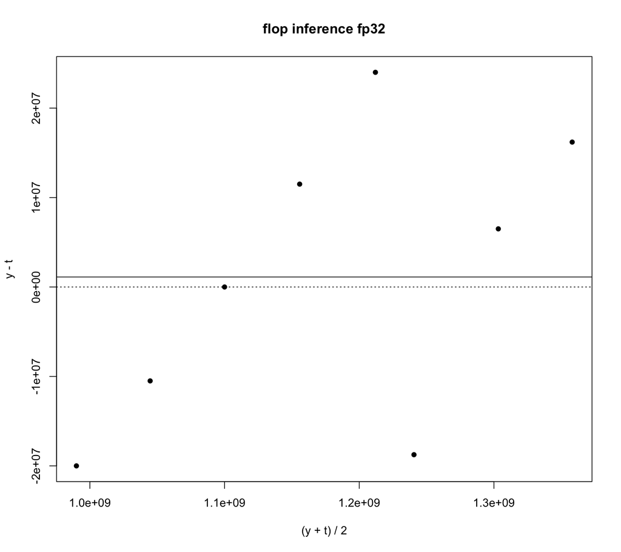

Figure 6: Bland Altman panels for each phase, precision, and hypothesis. The horizontal axis is the pairwise average and the vertical axis is the signed difference.

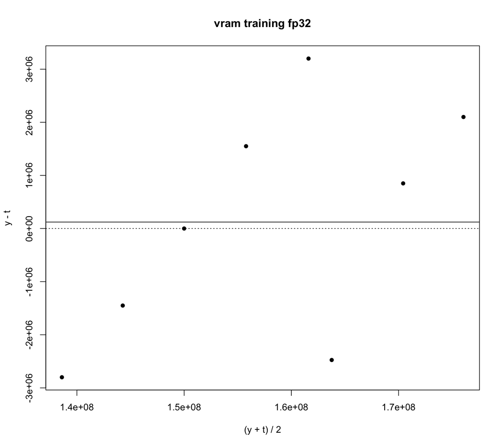

Figure 7: Bland Altman panels for each phase, precision, and hypothesis. The horizontal axis is the pairwise average and the vertical axis is the signed difference.

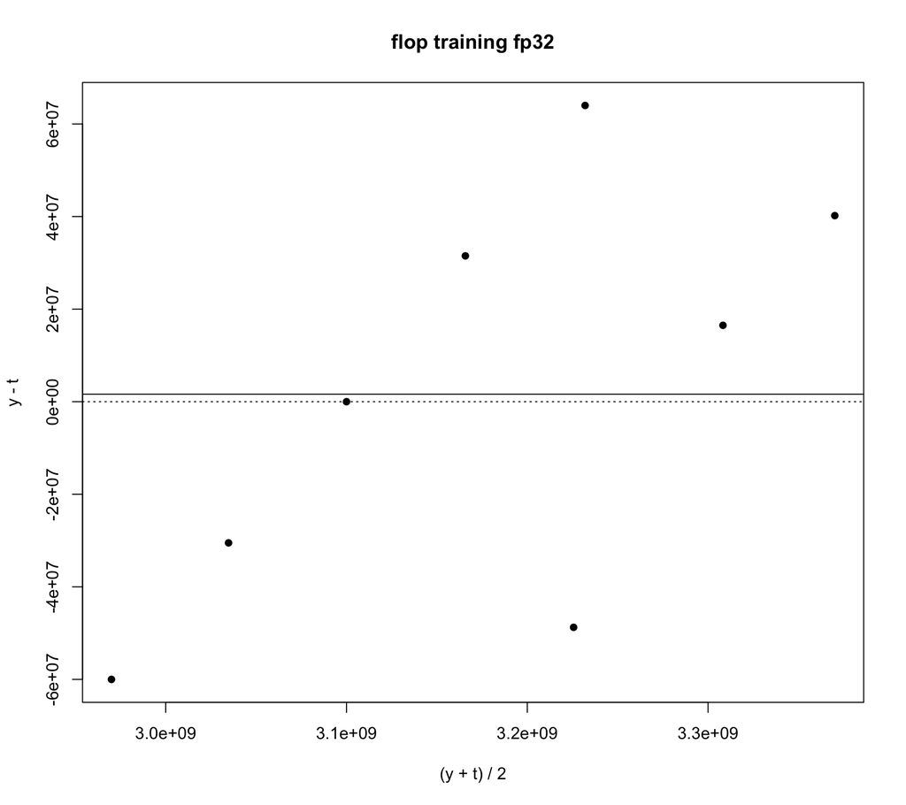

Figure 8: Bland Altman panels for each phase, precision, and hypothesis. The horizontal axis is the pairwise average and the vertical axis is the signed difference.

```r
old_par <- par(mfrow = c(4, 2), mar = c(4, 4, 3, 1))
on.exit(par(old_par), add = TRUE)

for (i in seq_len(nrow(cells))) {
  hyp <- cells$hypothesis[[i]]
  phase <- cells$phase[[i]]
  precision <- cells$precision[[i]]
  part <- evaluation[
    evaluation$phase == phase & evaluation$precision == precision,
  ]
  part <- part[!duplicated(part$subject_id), ]
  y <- if (hyp == "vram") part$y_vram else part$y_flop_fcm
  t <- if (hyp == "vram") part$target_vram else part$target_flop
  average <- (y + t) / 2
  difference <- y - t
  mean_diff <- mean(difference)
  loa <- 1.96 * sd(difference)

  plot(
    average,
    difference,
    xlab = "(y + t) / 2",
    ylab = "y - t",
    main = paste(hyp, phase, precision),
    pch = 16
  )
  abline(h = 0, lty = 3)
  abline(h = mean_diff, lty = 1)
  abline(h = mean_diff + loa, lty = 2)
  abline(h = mean_diff - loa, lty = 2)
}
```

# 6 Ledger as the sampling frame appendix

Builds that fail, including failures caused by exhausting memory, are recorded rather than omitted without comment. Those failed attempts do not enter the eight TOSTs.

```r
if (nrow(ledger) == 0) {
  cat("No ledger rows.\n")
} else {
  knitr::kable(ledger, caption = "Failed attempts. Primary analysis uses completed subjects only.")
}
```

Failed attempts. Primary analysis uses completed subjects only.

| subject_id | configuration_id | phase | precision | seq_len | batch_size | failure_kind | message |
| --- | --- | --- | --- | --- | --- | --- | --- |
| uncollected | uncollected | training | fp16 | 128 | 4 | oom | CUDA out of memory (fixture) |